# Risk Factor Analysis

## Outcome Variable

**Outcome Variable:** ever_stunted

## Predictor Variables

**Intervention Variable:** hhwealth_quart

**Adjustment Set:**

- arm
- sex
- W_mage
- meducyrs
- feducyrs
- W_gagebrth
- W_birthwt
- W_birthlen
- W_nchldlt5
- W_parity
- delta_sex
- delta_W_mage
- delta_meducyrs
- delta_feducyrs
- delta_W_gagebrth
- delta_W_birthwt
- delta_W_birthlen
- delta_W_nchldlt5
- delta_W_parity

## Stratifying Variables

The analysis was stratified on these variable(s):

- agecat
- studyid
- country

## Data Summary

| agecat | studyid | country | hhwealth_quart | ever_stunted | n_cell | n |
| --- | --- | --- | --- | --- | --- | --- |
| 0-24 months | ki0047075b-MAL-ED | BANGLADESH | Wealth Q4 | 0 | 7 | 82 |
| 0-24 months | ki0047075b-MAL-ED | BANGLADESH | Wealth Q4 | 1 | 14 | 82 |
| 0-24 months | ki0047075b-MAL-ED | BANGLADESH | Wealth Q1 | 0 | 6 | 82 |
| 0-24 months | ki0047075b-MAL-ED | BANGLADESH | Wealth Q1 | 1 | 15 | 82 |
| 0-24 months | ki0047075b-MAL-ED | BANGLADESH | Wealth Q2 | 0 | 8 | 82 |
| 0-24 months | ki0047075b-MAL-ED | BANGLADESH | Wealth Q2 | 1 | 12 | 82 |
| 0-24 months | ki0047075b-MAL-ED | BANGLADESH | Wealth Q3 | 0 | 8 | 82 |
| 0-24 months | ki0047075b-MAL-ED | BANGLADESH | Wealth Q3 | 1 | 12 | 82 |
| 0-24 months | ki0047075b-MAL-ED | INDIA | Wealth Q4 | 0 | 6 | 71 |
| 0-24 months | ki0047075b-MAL-ED | INDIA | Wealth Q4 | 1 | 12 | 71 |
| 0-24 months | ki0047075b-MAL-ED | INDIA | Wealth Q1 | 0 | 9 | 71 |
| 0-24 months | ki0047075b-MAL-ED | INDIA | Wealth Q1 | 1 | 10 | 71 |
| 0-24 months | ki0047075b-MAL-ED | INDIA | Wealth Q2 | 0 | 10 | 71 |
| 0-24 months | ki0047075b-MAL-ED | INDIA | Wealth Q2 | 1 | 7 | 71 |
| 0-24 months | ki0047075b-MAL-ED | INDIA | Wealth Q3 | 0 | 4 | 71 |
| 0-24 months | ki0047075b-MAL-ED | INDIA | Wealth Q3 | 1 | 13 | 71 |
| 0-24 months | ki0047075b-MAL-ED | NEPAL | Wealth Q4 | 0 | 4 | 42 |
| 0-24 months | ki0047075b-MAL-ED | NEPAL | Wealth Q4 | 1 | 7 | 42 |
| 0-24 months | ki0047075b-MAL-ED | NEPAL | Wealth Q1 | 0 | 6 | 42 |
| 0-24 months | ki0047075b-MAL-ED | NEPAL | Wealth Q1 | 1 | 5 | 42 |
| 0-24 months | ki0047075b-MAL-ED | NEPAL | Wealth Q2 | 0 | 4 | 42 |
| 0-24 months | ki0047075b-MAL-ED | NEPAL | Wealth Q2 | 1 | 6 | 42 |
| 0-24 months | ki0047075b-MAL-ED | NEPAL | Wealth Q3 | 0 | 6 | 42 |
| 0-24 months | ki0047075b-MAL-ED | NEPAL | Wealth Q3 | 1 | 4 | 42 |
| 0-24 months | ki0047075b-MAL-ED | PERU | Wealth Q4 | 0 | 2 | 37 |
| 0-24 months | ki0047075b-MAL-ED | PERU | Wealth Q4 | 1 | 8 | 37 |
| 0-24 months | ki0047075b-MAL-ED | PERU | Wealth Q1 | 0 | 2 | 37 |
| 0-24 months | ki0047075b-MAL-ED | PERU | Wealth Q1 | 1 | 7 | 37 |
| 0-24 months | ki0047075b-MAL-ED | PERU | Wealth Q2 | 0 | 0 | 37 |
| 0-24 months | ki0047075b-MAL-ED | PERU | Wealth Q2 | 1 | 9 | 37 |

[output cut: 378 more lines]

The following strata were considered:

- agecat: 0-24 months, studyid: ki0047075b-MAL-ED, country: BANGLADESH
- agecat: 0-24 months, studyid: ki0047075b-MAL-ED, country: INDIA
- agecat: 0-24 months, studyid: ki0047075b-MAL-ED, country: NEPAL
- agecat: 0-24 months, studyid: ki0047075b-MAL-ED, country: PERU
- agecat: 0-24 months, studyid: ki0047075b-MAL-ED, country: SOUTH AFRICA
- agecat: 0-24 months, studyid: ki0047075b-MAL-ED, country: TANZANIA, UNITED REPUBLIC OF
- agecat: 0-24 months, studyid: ki1000108-CMC-V-BCS-2002, country: INDIA
- agecat: 0-24 months, studyid: ki1000108-IRC, country: INDIA
- agecat: 0-24 months, studyid: ki1017093b-PROVIDE, country: BANGLADESH
- agecat: 0-24 months, studyid: ki1066203-TanzaniaChild2, country: TANZANIA, UNITED REPUBLIC OF
- agecat: 0-24 months, studyid: ki1113344-GMS-Nepal, country: NEPAL
- agecat: 0-24 months, studyid: ki1114097-CONTENT, country: PERU
- agecat: 0-24 months, studyid: ki1135781-COHORTS, country: GUATEMALA
- agecat: 0-24 months, studyid: ki1135781-COHORTS, country: PHILIPPINES
- agecat: 0-24 months, studyid: ki1148112-LCNI-5, country: MALAWI
- agecat: 0-24 months, studyid: kiGH5241-JiVitA-3, country: BANGLADESH
- agecat: 0-24 months, studyid: kiGH5241-JiVitA-4, country: BANGLADESH
- agecat: 0-6 months, studyid: ki0047075b-MAL-ED, country: BANGLADESH
- agecat: 0-6 months, studyid: ki0047075b-MAL-ED, country: INDIA
- agecat: 0-6 months, studyid: ki0047075b-MAL-ED, country: NEPAL
- agecat: 0-6 months, studyid: ki0047075b-MAL-ED, country: PERU
- agecat: 0-6 months, studyid: ki0047075b-MAL-ED, country: SOUTH AFRICA
- agecat: 0-6 months, studyid: ki0047075b-MAL-ED, country: TANZANIA, UNITED REPUBLIC OF
- agecat: 0-6 months, studyid: ki1000108-CMC-V-BCS-2002, country: INDIA
- agecat: 0-6 months, studyid: ki1000108-IRC, country: INDIA
- agecat: 0-6 months, studyid: ki1017093b-PROVIDE, country: BANGLADESH
- agecat: 0-6 months, studyid: ki1066203-TanzaniaChild2, country: TANZANIA, UNITED REPUBLIC OF
- agecat: 0-6 months, studyid: ki1113344-GMS-Nepal, country: NEPAL
- agecat: 0-6 months, studyid: ki1114097-CONTENT, country: PERU
- agecat: 0-6 months, studyid: ki1135781-COHORTS, country: GUATEMALA
- agecat: 0-6 months, studyid: ki1135781-COHORTS, country: PHILIPPINES
- agecat: 0-6 months, studyid: ki1148112-LCNI-5, country: MALAWI
- agecat: 0-6 months, studyid: kiGH5241-JiVitA-3, country: BANGLADESH
- agecat: 0-6 months, studyid: kiGH5241-JiVitA-4, country: BANGLADESH
- agecat: 6-24 months, studyid: ki0047075b-MAL-ED, country: BANGLADESH
- agecat: 6-24 months, studyid: ki0047075b-MAL-ED, country: INDIA
- agecat: 6-24 months, studyid: ki0047075b-MAL-ED, country: NEPAL
- agecat: 6-24 months, studyid: ki0047075b-MAL-ED, country: PERU
- agecat: 6-24 months, studyid: ki0047075b-MAL-ED, country: SOUTH AFRICA
- agecat: 6-24 months, studyid: ki0047075b-MAL-ED, country: TANZANIA, UNITED REPUBLIC OF
- agecat: 6-24 months, studyid: ki1000108-CMC-V-BCS-2002, country: INDIA
- agecat: 6-24 months, studyid: ki1000108-IRC, country: INDIA
- agecat: 6-24 months, studyid: ki1017093b-PROVIDE, country: BANGLADESH
- agecat: 6-24 months, studyid: ki1066203-TanzaniaChild2, country: TANZANIA, UNITED REPUBLIC OF
- agecat: 6-24 months, studyid: ki1113344-GMS-Nepal, country: NEPAL
- agecat: 6-24 months, studyid: ki1114097-CONTENT, country: PERU
- agecat: 6-24 months, studyid: ki1135781-COHORTS, country: GUATEMALA
- agecat: 6-24 months, studyid: ki1135781-COHORTS, country: PHILIPPINES
- agecat: 6-24 months, studyid: ki1148112-LCNI-5, country: MALAWI
- agecat: 6-24 months, studyid: kiGH5241-JiVitA-3, country: BANGLADESH
- agecat: 6-24 months, studyid: kiGH5241-JiVitA-4, country: BANGLADESH

### Dropped Strata

Some strata were dropped due to rare outcomes:

- agecat: 0-24 months, studyid: ki0047075b-MAL-ED, country: INDIA
- agecat: 0-24 months, studyid: ki0047075b-MAL-ED, country: NEPAL
- agecat: 0-24 months, studyid: ki0047075b-MAL-ED, country: PERU
- agecat: 0-24 months, studyid: ki0047075b-MAL-ED, country: TANZANIA, UNITED REPUBLIC OF
- agecat: 0-6 months, studyid: ki0047075b-MAL-ED, country: BANGLADESH
- agecat: 0-6 months, studyid: ki0047075b-MAL-ED, country: NEPAL
- agecat: 0-6 months, studyid: ki0047075b-MAL-ED, country: PERU
- agecat: 0-6 months, studyid: ki0047075b-MAL-ED, country: SOUTH AFRICA
- agecat: 0-6 months, studyid: ki0047075b-MAL-ED, country: TANZANIA, UNITED REPUBLIC OF
- agecat: 6-24 months, studyid: ki0047075b-MAL-ED, country: BANGLADESH
- agecat: 6-24 months, studyid: ki0047075b-MAL-ED, country: INDIA
- agecat: 6-24 months, studyid: ki0047075b-MAL-ED, country: NEPAL
- agecat: 6-24 months, studyid: ki0047075b-MAL-ED, country: PERU
- agecat: 6-24 months, studyid: ki0047075b-MAL-ED, country: SOUTH AFRICA
- agecat: 6-24 months, studyid: ki0047075b-MAL-ED, country: TANZANIA, UNITED REPUBLIC OF
- agecat: 6-24 months, studyid: ki1114097-CONTENT, country: PERU

## Methods Detail

We’re interested in the causal parameters $E[Y_a]$ for all values of $a \in \mathcal{A}$. These parameters represent the mean outcome if, possibly contrary to fact, we intervened to set all units to have $A=a$. Under the randomization and positivity assumptions, these are identified by the statistical parameters $\psi_a=E_W[E_{Y|A,W}(Y|A=a,W)]$. In addition, we’re interested in the mean of $Y$, $E[Y]$ under no intervention (the observed mean). We will estimate these parameters by using SuperLearner to fit the relevant likelihood factors – $E_{Y|A,W}(Y|A=a,W)$ and $p(A=a|W)$, and then updating our likelihood fit using a joint TMLE.

For unadjusted analyses ($W=\{\}$), initial likelihoods were estimated using Lrnr_glm to estimate the simple $E(Y|A)$ and Lrnr_mean to estimate $p(A)$. For adjusted analyses, a small library containing Lrnr_glmnet, Lrnr_xgboost, and Lrnr_mean was used.

Having estimated these parameters, we will then use the delta method to estimate relative risks and attributable risks relative to a prespecified baseline level of $A$.

# Results Detail

## Results Plots

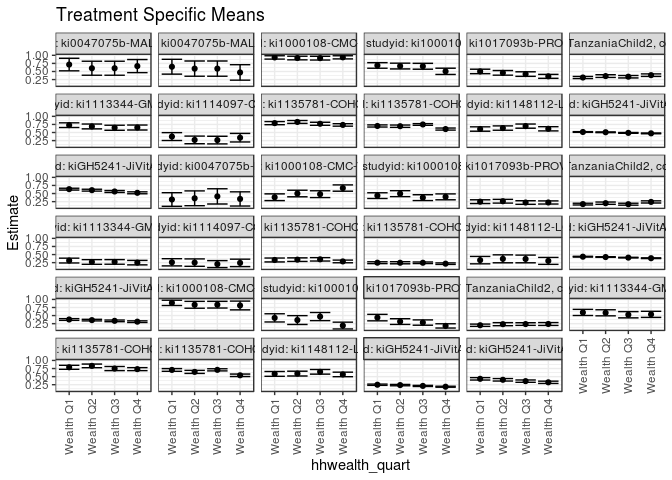

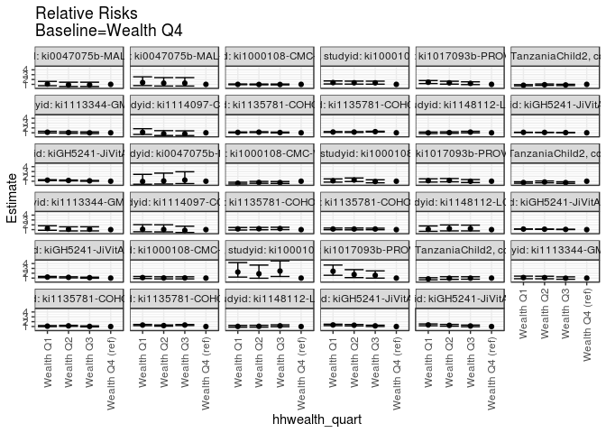

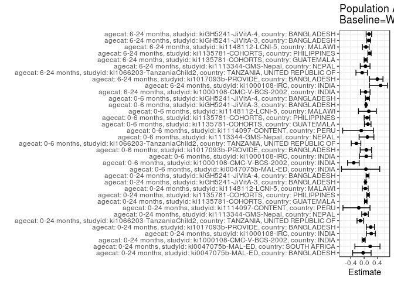

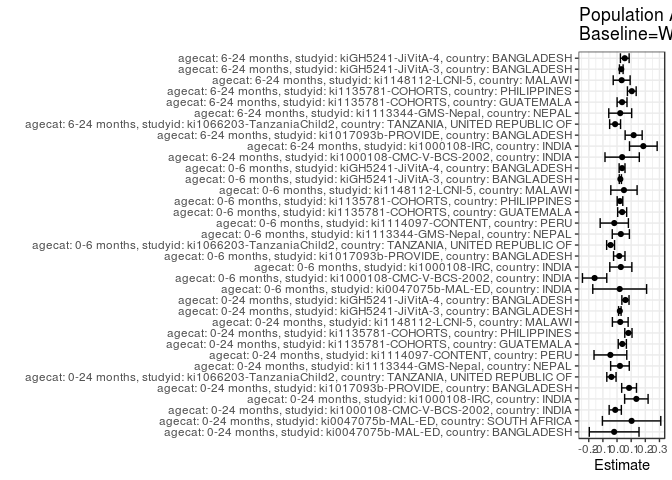

## Results Table

### Parameter: TSM

| agecat | studyid | country | intervention_level | baseline_level | estimate | ci_lower | ci_upper |
| --- | --- | --- | --- | --- | --- | --- | --- |
| 0-24 months | ki0047075b-MAL-ED | BANGLADESH | Wealth Q4 | NA | 0.6666667 | 0.4638066 | 0.8695268 |
| 0-24 months | ki0047075b-MAL-ED | BANGLADESH | Wealth Q1 | NA | 0.7142857 | 0.5198819 | 0.9086895 |
| 0-24 months | ki0047075b-MAL-ED | BANGLADESH | Wealth Q2 | NA | 0.6000000 | 0.3839754 | 0.8160246 |
| 0-24 months | ki0047075b-MAL-ED | BANGLADESH | Wealth Q3 | NA | 0.6000000 | 0.3839754 | 0.8160246 |
| 0-24 months | ki0047075b-MAL-ED | SOUTH AFRICA | Wealth Q4 | NA | 0.4705882 | 0.2315552 | 0.7096213 |
| 0-24 months | ki0047075b-MAL-ED | SOUTH AFRICA | Wealth Q1 | NA | 0.6470588 | 0.4182021 | 0.8759156 |
| 0-24 months | ki0047075b-MAL-ED | SOUTH AFRICA | Wealth Q2 | NA | 0.5882353 | 0.3525455 | 0.8239251 |
| 0-24 months | ki0047075b-MAL-ED | SOUTH AFRICA | Wealth Q3 | NA | 0.5882353 | 0.3525455 | 0.8239251 |
| 0-24 months | ki1000108-CMC-V-BCS-2002 | INDIA | Wealth Q4 | NA | 0.9375000 | 0.8890135 | 0.9859865 |
| 0-24 months | ki1000108-CMC-V-BCS-2002 | INDIA | Wealth Q1 | NA | 0.9340659 | 0.8830091 | 0.9851228 |
| 0-24 months | ki1000108-CMC-V-BCS-2002 | INDIA | Wealth Q2 | NA | 0.9157895 | 0.8598717 | 0.9717073 |
| 0-24 months | ki1000108-CMC-V-BCS-2002 | INDIA | Wealth Q3 | NA | 0.9120879 | 0.8538303 | 0.9703456 |
| 0-24 months | ki1000108-IRC | INDIA | Wealth Q4 | NA | 0.5047856 | 0.4079134 | 0.6016577 |
| 0-24 months | ki1000108-IRC | INDIA | Wealth Q1 | NA | 0.6860578 | 0.5998088 | 0.7723069 |
| 0-24 months | ki1000108-IRC | INDIA | Wealth Q2 | NA | 0.6674754 | 0.5786998 | 0.7562510 |
| 0-24 months | ki1000108-IRC | INDIA | Wealth Q3 | NA | 0.6610560 | 0.5702243 | 0.7518878 |
| 0-24 months | ki1017093b-PROVIDE | BANGLADESH | Wealth Q4 | NA | 0.3488776 | 0.2883063 | 0.4094489 |
| 0-24 months | ki1017093b-PROVIDE | BANGLADESH | Wealth Q1 | NA | 0.5015725 | 0.4324647 | 0.5706803 |
| 0-24 months | ki1017093b-PROVIDE | BANGLADESH | Wealth Q2 | NA | 0.4573318 | 0.3856468 | 0.5290168 |
| 0-24 months | ki1017093b-PROVIDE | BANGLADESH | Wealth Q3 | NA | 0.4200479 | 0.3497851 | 0.4903106 |
| 0-24 months | ki1066203-TanzaniaChild2 | TANZANIA, UNITED REPUBLIC OF | Wealth Q4 | NA | 0.3864709 | 0.3481596 | 0.4247822 |
| 0-24 months | ki1066203-TanzaniaChild2 | TANZANIA, UNITED REPUBLIC OF | Wealth Q1 | NA | 0.3136252 | 0.2804414 | 0.3468090 |
| 0-24 months | ki1066203-TanzaniaChild2 | TANZANIA, UNITED REPUBLIC OF | Wealth Q2 | NA | 0.3575858 | 0.3154398 | 0.3997319 |
| 0-24 months | ki1066203-TanzaniaChild2 | TANZANIA, UNITED REPUBLIC OF | Wealth Q3 | NA | 0.3383067 | 0.3004544 | 0.3761590 |
| 0-24 months | ki1113344-GMS-Nepal | NEPAL | Wealth Q4 | NA | 0.6537873 | 0.5772972 | 0.7302774 |
| 0-24 months | ki1113344-GMS-Nepal | NEPAL | Wealth Q1 | NA | 0.7271437 | 0.6551075 | 0.7991798 |
| 0-24 months | ki1113344-GMS-Nepal | NEPAL | Wealth Q2 | NA | 0.6872961 | 0.6125049 | 0.7620873 |
| 0-24 months | ki1113344-GMS-Nepal | NEPAL | Wealth Q3 | NA | 0.6472798 | 0.5693139 | 0.7252458 |
| 0-24 months | ki1114097-CONTENT | PERU | Wealth Q4 | NA | 0.3399846 | 0.2075747 | 0.4723946 |
| 0-24 months | ki1114097-CONTENT | PERU | Wealth Q1 | NA | 0.3744911 | 0.2523844 | 0.4965979 |

[output cut: 110 more lines]

### Parameter: E(Y)

| agecat | studyid | country | intervention_level | baseline_level | estimate | ci_lower | ci_upper |
| --- | --- | --- | --- | --- | --- | --- | --- |
| 0-24 months | ki0047075b-MAL-ED | BANGLADESH | NA | NA | 0.6463415 | 0.5422228 | 0.7504601 |
| 0-24 months | ki0047075b-MAL-ED | SOUTH AFRICA | NA | NA | 0.5735294 | 0.4551072 | 0.6919516 |
| 0-24 months | ki1000108-CMC-V-BCS-2002 | INDIA | NA | NA | 0.9249330 | 0.8981563 | 0.9517096 |
| 0-24 months | ki1000108-IRC | INDIA | NA | NA | 0.6414634 | 0.5949863 | 0.6879405 |
| 0-24 months | ki1017093b-PROVIDE | BANGLADESH | NA | NA | 0.4340974 | 0.3973018 | 0.4708930 |
| 0-24 months | ki1066203-TanzaniaChild2 | TANZANIA, UNITED REPUBLIC OF | NA | NA | 0.3468960 | 0.3277853 | 0.3660067 |
| 0-24 months | ki1113344-GMS-Nepal | NEPAL | NA | NA | 0.6744186 | 0.6369554 | 0.7118819 |
| 0-24 months | ki1114097-CONTENT | PERU | NA | NA | 0.2930233 | 0.2320422 | 0.3540043 |
| 0-24 months | ki1135781-COHORTS | GUATEMALA | NA | NA | 0.7715180 | 0.7484902 | 0.7945458 |
| 0-24 months | ki1135781-COHORTS | PHILIPPINES | NA | NA | 0.6866209 | 0.6701747 | 0.7030670 |
| 0-24 months | ki1148112-LCNI-5 | MALAWI | NA | NA | 0.6376989 | 0.6047193 | 0.6706785 |
| 0-24 months | kiGH5241-JiVitA-3 | BANGLADESH | NA | NA | 0.4938998 | 0.4860534 | 0.5017461 |
| 0-24 months | kiGH5241-JiVitA-4 | BANGLADESH | NA | NA | 0.5818282 | 0.5658219 | 0.5978346 |
| 0-6 months | ki0047075b-MAL-ED | INDIA | NA | NA | 0.3521127 | 0.2402231 | 0.4640023 |
| 0-6 months | ki1000108-CMC-V-BCS-2002 | INDIA | NA | NA | 0.5108696 | 0.4597270 | 0.5620121 |
| 0-6 months | ki1000108-IRC | INDIA | NA | NA | 0.4243902 | 0.3764905 | 0.4722900 |
| 0-6 months | ki1017093b-PROVIDE | BANGLADESH | NA | NA | 0.2392550 | 0.2075826 | 0.2709275 |
| 0-6 months | ki1066203-TanzaniaChild2 | TANZANIA, UNITED REPUBLIC OF | NA | NA | 0.1950503 | 0.1791413 | 0.2109594 |
| 0-6 months | ki1113344-GMS-Nepal | NEPAL | NA | NA | 0.2774086 | 0.2416141 | 0.3132032 |
| 0-6 months | ki1114097-CONTENT | PERU | NA | NA | 0.2232558 | 0.1674626 | 0.2790491 |
| 0-6 months | ki1135781-COHORTS | GUATEMALA | NA | NA | 0.3240116 | 0.2955133 | 0.3525098 |
| 0-6 months | ki1135781-COHORTS | PHILIPPINES | NA | NA | 0.2391233 | 0.2240003 | 0.2542464 |
| 0-6 months | ki1148112-LCNI-5 | MALAWI | NA | NA | 0.3531599 | 0.2959376 | 0.4103821 |
| 0-6 months | kiGH5241-JiVitA-3 | BANGLADESH | NA | NA | 0.4108893 | 0.4034376 | 0.4183410 |
| 0-6 months | kiGH5241-JiVitA-4 | BANGLADESH | NA | NA | 0.3474692 | 0.3322601 | 0.3626783 |
| 6-24 months | ki1000108-CMC-V-BCS-2002 | INDIA | NA | NA | 0.8486486 | 0.7968646 | 0.9004327 |
| 6-24 months | ki1000108-IRC | INDIA | NA | NA | 0.3771186 | 0.3151523 | 0.4390850 |
| 6-24 months | ki1017093b-PROVIDE | BANGLADESH | NA | NA | 0.2989011 | 0.2567922 | 0.3410100 |
| 6-24 months | ki1066203-TanzaniaChild2 | TANZANIA, UNITED REPUBLIC OF | NA | NA | 0.2268170 | 0.2062654 | 0.2473687 |
| 6-24 months | ki1113344-GMS-Nepal | NEPAL | NA | NA | 0.5610329 | 0.5138522 | 0.6082135 |
| 6-24 months | ki1135781-COHORTS | GUATEMALA | NA | NA | 0.7665094 | 0.7380190 | 0.7949999 |
| 6-24 months | ki1135781-COHORTS | PHILIPPINES | NA | NA | 0.6449788 | 0.6246093 | 0.6653483 |
| 6-24 months | ki1148112-LCNI-5 | MALAWI | NA | NA | 0.6000000 | 0.5639396 | 0.6360604 |
| 6-24 months | kiGH5241-JiVitA-3 | BANGLADESH | NA | NA | 0.2172797 | 0.2079084 | 0.2266510 |
| 6-24 months | kiGH5241-JiVitA-4 | BANGLADESH | NA | NA | 0.3784303 | 0.3598372 | 0.3970234 |

### Parameter: RR

| agecat | studyid | country | intervention_level | baseline_level | estimate | ci_lower | ci_upper |
| --- | --- | --- | --- | --- | --- | --- | --- |
| 0-24 months | ki0047075b-MAL-ED | BANGLADESH | Wealth Q4 | Wealth Q4 | 1.0000000 | 1.0000000 | 1.0000000 |
| 0-24 months | ki0047075b-MAL-ED | BANGLADESH | Wealth Q1 | Wealth Q4 | 1.0714286 | 0.7123007 | 1.6116217 |
| 0-24 months | ki0047075b-MAL-ED | BANGLADESH | Wealth Q2 | Wealth Q4 | 0.9000000 | 0.5617127 | 1.4420183 |
| 0-24 months | ki0047075b-MAL-ED | BANGLADESH | Wealth Q3 | Wealth Q4 | 0.9000000 | 0.5617127 | 1.4420183 |
| 0-24 months | ki0047075b-MAL-ED | SOUTH AFRICA | Wealth Q4 | Wealth Q4 | 1.0000000 | 1.0000000 | 1.0000000 |
| 0-24 months | ki0047075b-MAL-ED | SOUTH AFRICA | Wealth Q1 | Wealth Q4 | 1.3750000 | 0.7404481 | 2.5533526 |
| 0-24 months | ki0047075b-MAL-ED | SOUTH AFRICA | Wealth Q2 | Wealth Q4 | 1.2500000 | 0.6545492 | 2.3871392 |
| 0-24 months | ki0047075b-MAL-ED | SOUTH AFRICA | Wealth Q3 | Wealth Q4 | 1.2500000 | 0.6545492 | 2.3871392 |
| 0-24 months | ki1000108-CMC-V-BCS-2002 | INDIA | Wealth Q4 | Wealth Q4 | 1.0000000 | 1.0000000 | 1.0000000 |
| 0-24 months | ki1000108-CMC-V-BCS-2002 | INDIA | Wealth Q1 | Wealth Q4 | 0.9963370 | 0.9241135 | 1.0742051 |
| 0-24 months | ki1000108-CMC-V-BCS-2002 | INDIA | Wealth Q2 | Wealth Q4 | 0.9768421 | 0.9017212 | 1.0582212 |
| 0-24 months | ki1000108-CMC-V-BCS-2002 | INDIA | Wealth Q3 | Wealth Q4 | 0.9728938 | 0.8961328 | 1.0562300 |
| 0-24 months | ki1000108-IRC | INDIA | Wealth Q4 | Wealth Q4 | 1.0000000 | 1.0000000 | 1.0000000 |
| 0-24 months | ki1000108-IRC | INDIA | Wealth Q1 | Wealth Q4 | 1.3591075 | 1.0836494 | 1.7045855 |
| 0-24 months | ki1000108-IRC | INDIA | Wealth Q2 | Wealth Q4 | 1.3222950 | 1.0493880 | 1.6661749 |
| 0-24 months | ki1000108-IRC | INDIA | Wealth Q3 | Wealth Q4 | 1.3095780 | 1.0348476 | 1.6572435 |
| 0-24 months | ki1017093b-PROVIDE | BANGLADESH | Wealth Q4 | Wealth Q4 | 1.0000000 | 1.0000000 | 1.0000000 |
| 0-24 months | ki1017093b-PROVIDE | BANGLADESH | Wealth Q1 | Wealth Q4 | 1.4376745 | 1.1610132 | 1.7802622 |
| 0-24 months | ki1017093b-PROVIDE | BANGLADESH | Wealth Q2 | Wealth Q4 | 1.3108659 | 1.0464542 | 1.6420874 |
| 0-24 months | ki1017093b-PROVIDE | BANGLADESH | Wealth Q3 | Wealth Q4 | 1.2039977 | 0.9541743 | 1.5192302 |
| 0-24 months | ki1066203-TanzaniaChild2 | TANZANIA, UNITED REPUBLIC OF | Wealth Q4 | Wealth Q4 | 1.0000000 | 1.0000000 | 1.0000000 |
| 0-24 months | ki1066203-TanzaniaChild2 | TANZANIA, UNITED REPUBLIC OF | Wealth Q1 | Wealth Q4 | 0.8115106 | 0.7029097 | 0.9368905 |
| 0-24 months | ki1066203-TanzaniaChild2 | TANZANIA, UNITED REPUBLIC OF | Wealth Q2 | Wealth Q4 | 0.9252594 | 0.7939549 | 1.0782791 |
| 0-24 months | ki1066203-TanzaniaChild2 | TANZANIA, UNITED REPUBLIC OF | Wealth Q3 | Wealth Q4 | 0.8753743 | 0.7546240 | 1.0154463 |
| 0-24 months | ki1113344-GMS-Nepal | NEPAL | Wealth Q4 | Wealth Q4 | 1.0000000 | 1.0000000 | 1.0000000 |
| 0-24 months | ki1113344-GMS-Nepal | NEPAL | Wealth Q1 | Wealth Q4 | 1.1122021 | 0.9543395 | 1.2961777 |
| 0-24 months | ki1113344-GMS-Nepal | NEPAL | Wealth Q2 | Wealth Q4 | 1.0512533 | 0.8959533 | 1.2334723 |
| 0-24 months | ki1113344-GMS-Nepal | NEPAL | Wealth Q3 | Wealth Q4 | 0.9900465 | 0.8368230 | 1.1713254 |
| 0-24 months | ki1114097-CONTENT | PERU | Wealth Q4 | Wealth Q4 | 1.0000000 | 1.0000000 | 1.0000000 |
| 0-24 months | ki1114097-CONTENT | PERU | Wealth Q1 | Wealth Q4 | 1.1014943 | 0.6609716 | 1.8356155 |

[output cut: 110 more lines]

### Parameter: PAR

| agecat | studyid | country | intervention_level | baseline_level | estimate | ci_lower | ci_upper |
| --- | --- | --- | --- | --- | --- | --- | --- |
| 0-24 months | ki0047075b-MAL-ED | BANGLADESH | Wealth Q4 | NA | -0.0203252 | -0.1961517 | 0.1555013 |
| 0-24 months | ki0047075b-MAL-ED | SOUTH AFRICA | Wealth Q4 | NA | 0.1029412 | -0.1034377 | 0.3093200 |
| 0-24 months | ki1000108-CMC-V-BCS-2002 | INDIA | Wealth Q4 | NA | -0.0125670 | -0.0556692 | 0.0305351 |
| 0-24 months | ki1000108-IRC | INDIA | Wealth Q4 | NA | 0.1366779 | 0.0537452 | 0.2196105 |
| 0-24 months | ki1017093b-PROVIDE | BANGLADESH | Wealth Q4 | NA | 0.0852198 | 0.0328316 | 0.1376079 |
| 0-24 months | ki1066203-TanzaniaChild2 | TANZANIA, UNITED REPUBLIC OF | Wealth Q4 | NA | -0.0395749 | -0.0723130 | -0.0068368 |
| 0-24 months | ki1113344-GMS-Nepal | NEPAL | Wealth Q4 | NA | 0.0206313 | -0.0452351 | 0.0864977 |
| 0-24 months | ki1114097-CONTENT | PERU | Wealth Q4 | NA | -0.0469614 | -0.1627625 | 0.0688397 |
| 0-24 months | ki1135781-COHORTS | GUATEMALA | Wealth Q4 | NA | 0.0373286 | 0.0084300 | 0.0662271 |
| 0-24 months | ki1135781-COHORTS | PHILIPPINES | Wealth Q4 | NA | 0.0803304 | 0.0547586 | 0.1059022 |
| 0-24 months | ki1148112-LCNI-5 | MALAWI | Wealth Q4 | NA | 0.0228329 | -0.0327845 | 0.0784502 |
| 0-24 months | kiGH5241-JiVitA-3 | BANGLADESH | Wealth Q4 | NA | 0.0198113 | 0.0109730 | 0.0286495 |
| 0-24 months | kiGH5241-JiVitA-4 | BANGLADESH | Wealth Q4 | NA | 0.0594729 | 0.0341938 | 0.0847520 |
| 0-6 months | ki0047075b-MAL-ED | INDIA | Wealth Q4 | NA | 0.0187793 | -0.1715677 | 0.2091264 |
| 0-6 months | ki1000108-CMC-V-BCS-2002 | INDIA | Wealth Q4 | NA | -0.1585652 | -0.2445307 | -0.0725997 |
| 0-6 months | ki1000108-IRC | INDIA | Wealth Q4 | NA | 0.0268507 | -0.0511053 | 0.1048067 |
| 0-6 months | ki1017093b-PROVIDE | BANGLADESH | Wealth Q4 | NA | 0.0157761 | -0.0245604 | 0.0561126 |
| 0-6 months | ki1066203-TanzaniaChild2 | TANZANIA, UNITED REPUBLIC OF | Wealth Q4 | NA | -0.0455377 | -0.0734445 | -0.0176309 |
| 0-6 months | ki1113344-GMS-Nepal | NEPAL | Wealth Q4 | NA | 0.0268536 | -0.0337227 | 0.0874299 |
| 0-6 months | ki1114097-CONTENT | PERU | Wealth Q4 | NA | -0.0194371 | -0.1192415 | 0.0803673 |
| 0-6 months | ki1135781-COHORTS | GUATEMALA | Wealth Q4 | NA | 0.0363149 | 0.0045244 | 0.0681054 |
| 0-6 months | ki1135781-COHORTS | PHILIPPINES | Wealth Q4 | NA | 0.0208515 | 0.0009879 | 0.0407150 |
| 0-6 months | ki1148112-LCNI-5 | MALAWI | Wealth Q4 | NA | 0.0489633 | -0.0439789 | 0.1419055 |
| 0-6 months | kiGH5241-JiVitA-3 | BANGLADESH | Wealth Q4 | NA | 0.0235232 | 0.0159075 | 0.0311390 |
| 0-6 months | kiGH5241-JiVitA-4 | BANGLADESH | Wealth Q4 | NA | 0.0355362 | 0.0148489 | 0.0562234 |
| 6-24 months | ki1000108-CMC-V-BCS-2002 | INDIA | Wealth Q4 | NA | 0.0361486 | -0.0851282 | 0.1574255 |
| 6-24 months | ki1000108-IRC | INDIA | Wealth Q4 | NA | 0.1859255 | 0.0881525 | 0.2836986 |
| 6-24 months | ki1017093b-PROVIDE | BANGLADESH | Wealth Q4 | NA | 0.1174431 | 0.0572485 | 0.1776378 |
| 6-24 months | ki1066203-TanzaniaChild2 | TANZANIA, UNITED REPUBLIC OF | Wealth Q4 | NA | -0.0136428 | -0.0522849 | 0.0249994 |
| 6-24 months | ki1113344-GMS-Nepal | NEPAL | Wealth Q4 | NA | 0.0225702 | -0.0583722 | 0.1035126 |
| 6-24 months | ki1135781-COHORTS | GUATEMALA | Wealth Q4 | NA | 0.0354492 | 0.0004403 | 0.0704580 |
| 6-24 months | ki1135781-COHORTS | PHILIPPINES | Wealth Q4 | NA | 0.1044236 | 0.0735452 | 0.1353020 |
| 6-24 months | ki1148112-LCNI-5 | MALAWI | Wealth Q4 | NA | 0.0327998 | -0.0270093 | 0.0926089 |
| 6-24 months | kiGH5241-JiVitA-3 | BANGLADESH | Wealth Q4 | NA | 0.0300024 | 0.0171080 | 0.0428968 |
| 6-24 months | kiGH5241-JiVitA-4 | BANGLADESH | Wealth Q4 | NA | 0.0547736 | 0.0239954 | 0.0855517 |

### Parameter: PAF

| agecat | studyid | country | intervention_level | baseline_level | estimate | ci_lower | ci_upper |
| --- | --- | --- | --- | --- | --- | --- | --- |
| 0-24 months | ki0047075b-MAL-ED | BANGLADESH | Wealth Q4 | NA | -0.0314465 | -0.3428961 | 0.2077705 |
| 0-24 months | ki0047075b-MAL-ED | SOUTH AFRICA | Wealth Q4 | NA | 0.1794872 | -0.2757414 | 0.4722745 |
| 0-24 months | ki1000108-CMC-V-BCS-2002 | INDIA | Wealth Q4 | NA | -0.0135870 | -0.0613168 | 0.0319963 |
| 0-24 months | ki1000108-IRC | INDIA | Wealth Q4 | NA | 0.2130720 | 0.0706648 | 0.3336573 |
| 0-24 months | ki1017093b-PROVIDE | BANGLADESH | Wealth Q4 | NA | 0.1963149 | 0.0669233 | 0.3077635 |
| 0-24 months | ki1066203-TanzaniaChild2 | TANZANIA, UNITED REPUBLIC OF | Wealth Q4 | NA | -0.1140830 | -0.2126296 | -0.0235449 |
| 0-24 months | ki1113344-GMS-Nepal | NEPAL | Wealth Q4 | NA | 0.0305912 | -0.0722196 | 0.1235439 |
| 0-24 months | ki1114097-CONTENT | PERU | Wealth Q4 | NA | -0.1602651 | -0.6317389 | 0.1749814 |
| 0-24 months | ki1135781-COHORTS | GUATEMALA | Wealth Q4 | NA | 0.0483833 | 0.0100029 | 0.0852757 |
| 0-24 months | ki1135781-COHORTS | PHILIPPINES | Wealth Q4 | NA | 0.1169938 | 0.0786370 | 0.1537538 |
| 0-24 months | ki1148112-LCNI-5 | MALAWI | Wealth Q4 | NA | 0.0358051 | -0.0555350 | 0.1192412 |
| 0-24 months | kiGH5241-JiVitA-3 | BANGLADESH | Wealth Q4 | NA | 0.0401119 | 0.0220551 | 0.0578354 |
| 0-24 months | kiGH5241-JiVitA-4 | BANGLADESH | Wealth Q4 | NA | 0.1022173 | 0.0575474 | 0.1447700 |
| 0-6 months | ki0047075b-MAL-ED | INDIA | Wealth Q4 | NA | 0.0533333 | -0.6757167 | 0.4651973 |
| 0-6 months | ki1000108-CMC-V-BCS-2002 | INDIA | Wealth Q4 | NA | -0.3103829 | -0.4950907 | -0.1484945 |
| 0-6 months | ki1000108-IRC | INDIA | Wealth Q4 | NA | 0.0632688 | -0.1397345 | 0.2301143 |
| 0-6 months | ki1017093b-PROVIDE | BANGLADESH | Wealth Q4 | NA | 0.0659383 | -0.1178851 | 0.2195340 |
| 0-6 months | ki1066203-TanzaniaChild2 | TANZANIA, UNITED REPUBLIC OF | Wealth Q4 | NA | -0.2334664 | -0.3847117 | -0.0987408 |
| 0-6 months | ki1113344-GMS-Nepal | NEPAL | Wealth Q4 | NA | 0.0968016 | -0.1501029 | 0.2907005 |
| 0-6 months | ki1114097-CONTENT | PERU | Wealth Q4 | NA | -0.0870621 | -0.6402510 | 0.2795591 |
| 0-6 months | ki1135781-COHORTS | GUATEMALA | Wealth Q4 | NA | 0.1120791 | 0.0082610 | 0.2050291 |
| 0-6 months | ki1135781-COHORTS | PHILIPPINES | Wealth Q4 | NA | 0.0871996 | 0.0005017 | 0.1663773 |
| 0-6 months | ki1148112-LCNI-5 | MALAWI | Wealth Q4 | NA | 0.1386435 | -0.1691614 | 0.3654127 |
| 0-6 months | kiGH5241-JiVitA-3 | BANGLADESH | Wealth Q4 | NA | 0.0572496 | 0.0385523 | 0.0755832 |
| 0-6 months | kiGH5241-JiVitA-4 | BANGLADESH | Wealth Q4 | NA | 0.1022714 | 0.0405698 | 0.1600049 |
| 6-24 months | ki1000108-CMC-V-BCS-2002 | INDIA | Wealth Q4 | NA | 0.0425955 | -0.1117937 | 0.1755455 |
| 6-24 months | ki1000108-IRC | INDIA | Wealth Q4 | NA | 0.4930160 | 0.1591762 | 0.6943084 |
| 6-24 months | ki1017093b-PROVIDE | BANGLADESH | Wealth Q4 | NA | 0.3929164 | 0.1602222 | 0.5611333 |
| 6-24 months | ki1066203-TanzaniaChild2 | TANZANIA, UNITED REPUBLIC OF | Wealth Q4 | NA | -0.0601487 | -0.2449095 | 0.0971912 |
| 6-24 months | ki1113344-GMS-Nepal | NEPAL | Wealth Q4 | NA | 0.0402297 | -0.1155519 | 0.1742571 |
| 6-24 months | ki1135781-COHORTS | GUATEMALA | Wealth Q4 | NA | 0.0462476 | -0.0007134 | 0.0910048 |
| 6-24 months | ki1135781-COHORTS | PHILIPPINES | Wealth Q4 | NA | 0.1619024 | 0.1120568 | 0.2089498 |
| 6-24 months | ki1148112-LCNI-5 | MALAWI | Wealth Q4 | NA | 0.0546664 | -0.0505827 | 0.1493715 |
| 6-24 months | kiGH5241-JiVitA-3 | BANGLADESH | Wealth Q4 | NA | 0.1380819 | 0.0771918 | 0.1949542 |
| 6-24 months | kiGH5241-JiVitA-4 | BANGLADESH | Wealth Q4 | NA | 0.1447389 | 0.0595666 | 0.2221974 |